# ML_project_TiU-7

We are doing forward feature selection

```python
selected_features = []
remaining_features = list(X_train.columns)
best_mse = float('inf')
best_features = []

while remaining_features:
    mse_with_features = {}

    for feature in remaining_features:
        current_features = selected_features + [feature]

        # Scale data
        scaler = StandardScaler()
        X_train_scaled = scaler.fit_transform(X_train[current_features])
        X_test_scaled = scaler.transform(X_test[current_features])

            # Train model
        model = LinearRegression()
        model.fit(X_train_scaled, y_train)

            # Evaluate model
        y_pred = model.predict(X_test_scaled)
        mse = mean_squared_error(y_test, y_pred)
        mse_with_features[feature] = mse

        # Find the feature that gives the best improvement
    best_feature = min(mse_with_features, key=mse_with_features.get)
    best_feature_mse = mse_with_features[best_feature]

    if best_feature_mse < best_mse:
        selected_features.append(best_feature)
        remaining_features.remove(best_feature)
        best_mse = best_feature_mse
        best_features = selected_features.copy()
    else:
        break

print("Best Features:", best_features)
print("Best MSE:", best_mse)
print("size:", len(best_features))
```

```
Best Features: ['Median_Income', 'Distance_to_coast', 'Median_Age', 'Tot_Bedrooms', 'Population', 'Tot_Rooms', 'Distance_to_LA', 'Longitude', 'Latitude', 'Households', 'Distance_to_SanDiego', 'Distance_to_SanJose', 'Distance_to_SanFrancisco']
Best MSE: 4610948091.588843
size: 13
```

So, linear regression works better when we take all variables.

```python
selected_features = []
remaining_features = list(X_train.columns)
best_mse = float('inf')
best_features = []

while remaining_features:
    mse_with_features = {}

    for feature in remaining_features:
        current_features = selected_features + [feature]

            # Scale data
        scaler = StandardScaler()
        X_train_scaled = scaler.fit_transform(X_train[current_features])
        X_test_scaled = scaler.transform(X_test[current_features])

            # Train XGBoost model
        model = XGBRegressor(objective='reg:squarederror', n_estimators=100, learning_rate=0.1)
        model.fit(X_train_scaled, y_train)

            # Evaluate model
        y_pred = model.predict(X_test_scaled)
        mse = mean_squared_error(y_test, y_pred)
        mse_with_features[feature] = mse

        # Find the feature that gives the best improvement
    best_feature = min(mse_with_features, key=mse_with_features.get)
    best_feature_mse = mse_with_features[best_feature]

    if best_feature_mse < best_mse:
        selected_features.append(best_feature)
        remaining_features.remove(best_feature)
        best_mse = best_feature_mse
        best_features = selected_features.copy()
    else:
        break


print("Best Features:", best_features)
print("Best MSE:", best_mse)
print('size:', len(best_features))
```

```
Best Features: ['Median_Income', 'Distance_to_SanFrancisco', 'Latitude', 'Longitude', 'Distance_to_SanJose', 'Distance_to_LA', 'Distance_to_SanDiego']
Best MSE: 2502679100.4018784
size: 7
```

Let's also check how important are variables that we want to drop out (Distances to SF and SD + Households) for XGBoost.

```python
model = XGBRegressor(objective='reg:squarederror', n_estimators=100, learning_rate=0.1)
model.fit(X_train_scaled, y_train)
y_pred = model.predict(X_test_scaled)
mse = mean_squared_error(y_test, y_pred)
r2 = r2_score(y_test, y_pred)
print('Mean Squared Error:', mse)
print('R^2 Score:', r2)
```

```
Mean Squared Error: 2111510207.5327537
R^2 Score: 0.8340471975092072
```

```python
import xgboost as xgb
```

[figure not shown]

```python
importance = model.feature_importances_
feature_names = features_list

# Create a DataFrame for sorting
importance_df = pd.DataFrame({
    'Feature': feature_names,
    'Importance': importance
}).sort_values(by='Importance', ascending=False)

# Plot feature importance
plt.figure(figsize=(10, 6))
plt.barh(importance_df['Feature'], importance_df['Importance'], color='skyblue')
plt.xlabel('Importance Score')
plt.ylabel('Features')
plt.title('Feature Importance in XGBoost')
plt.gca().invert_yaxis()  # Invert y-axis for descending order
plt.show()
```

Here we see that with XGBoost the best prediction is coming only from using 7 variables.

Most of them are distance variables and neighborhood properties variables are not even in the list.

And if we check for feature importance, we get that Distance to SF is indeed important.

XGBoost is the best model we have and we want to target to get the best predictions from it.

However, there is a trade-off:

1. XGBoost prefers to have more distance variables as distance to a city seem to be significant for this model
2. Possible problem with linear regressions can arise in case we leave everything as it is

Now let's summarize everything:

1. Distances are important for XGBoost. XGBoost doesn't care about multicollinearity.
2. Distances are multicolinear and it will lead to problems with linear regressions
3. XGBoost outperforms Linear models.
4. Households are almost not important for the XGBoost but lead to multicolinearity problems

Therefore, our final decision is to:

1. Leave all distances as they can be important. Cost of it: possible problems with linear regressions with some gains in XGBoost.
2. Omit Households variable.

Additional note:

What we also tried to do is to code all distances. The general idea was to code neighborhoods that are in the cities and check the results. This somehow solved the multicolinearity problem

However, this led to 2 problems:

1. It is very hard to say which neighborhoods are in the city and which are not. Also we need to take agglomearionts into account.
2. Many neighborhoods didn't get any class at all: possible data loss.

Results were usually lower for both models.

```python
features_list=['Median_Income','Median_Age',
               'Tot_Rooms','Tot_Bedrooms','Population',
               #'Households',
               'Latitude','Longitude',
               'Distance_to_coast',
               'Distance_to_LA',
              'Distance_to_SanJose'
               ,'Distance_to_SanDiego','Distance_to_SanFrancisco'
               ]


y=data['Median_House_Value']
X=data[features_list]

X_train, X_test, y_train, y_test = train_test_split(X, y, test_size=0.3, random_state=40)
scaler=StandardScaler()
X_train_scaled=scaler.fit_transform(X_train)
X_test_scaled=scaler.transform(X_test)
```

### Final results

```python
LRegression(X_train_scaled,y_train,X_test_scaled,y_test)
```

```
Model R^2: 0.6499150375504501
Model MAE: 49316.763816195016
Model MSE: 4619016653.256039
```

```python
DecisionTreeModel(X_train_scaled,y_train,X_test_scaled,y_test)
```

```
Test Mean Absolute Error: 42938.338772735
Test Mean Squared Error: 4633269260.487336
```

```python
XGBoost(X_train_scaled,y_train,X_test_scaled,y_test)
```

```
Mean Squared Error: 2337194506.5773325
R^2 Score: 0.8228591251136446
```

```python
min(2337194506.5773325 , 4633269260.487336 , 4619016653.256039  )
```

```
2337194506.5773325
```

Here we see what was expected at the beginning: XGBoost gives us the lowest MSE, while performance of the linear regression is not that accurate. Trees are even worse than Linear regression.

## Finetuning and cross-validation

First, we split data in training, validation and testing sets.

Testing set will be used only at the end.

```python
y=data['Median_House_Value']
X=data[features_list]

X_train, X_temp, y_train, y_temp = train_test_split(X, y, test_size=0.4, random_state=50)
X_val, X_test, y_val , y_test=train_test_split(X_temp, y_temp, test_size=0.5, random_state=50)
```

```python
scaler = StandardScaler()
X_train_scaled = scaler.fit_transform(X_train)
X_val_scaled = scaler.transform(X_val)
X_test_scaled=scaler.transform(X_test)
```

## Lasso

```python
lasso = Lasso(alpha=10,  max_iter=100000)  # alpha is the regularization strength
lasso.fit(X_train_scaled, y_train)

# Predictions
y_pred_lasso = lasso.predict(X_val_scaled)

# Evaluation
mse_lasso = mean_squared_error(y_val, y_pred_lasso)
r2_lasso = r2_score(y_val, y_pred_lasso)
print("Lasso Regression - MSE:", mse_lasso, "R2:", r2_lasso)
```

```
Lasso Regression - MSE: 4559547501.758495 R2: 0.6551128756997762
```

```python
lasso = Lasso(max_iter=20000)

# Define the parameter grid for alpha
param_grid = {
    "alpha": np.logspace(-4, 2, 50)  # Range of alpha values from 0.0001 to 100
}

# Define a custom scoring metric (e.g., negative mean squared error)
scorer = make_scorer(mean_squared_error, greater_is_better=False)

# Set up GridSearchCV
grid_search = GridSearchCV(estimator=lasso, param_grid=param_grid, scoring=scorer, cv=5, n_jobs=-1)

# Perform the grid search
grid_search.fit(X_train_scaled, y_train)

# Best parameters and corresponding score
best_alpha = grid_search.best_params_["alpha"]
best_score = -grid_search.best_score_  # Convert back to positive MSE

# Evaluate the best model on the test set
best_model = grid_search.best_estimator_
y_val_pred = best_model.predict(X_val_scaled)
val_mse = mean_squared_error(y_val, y_val_pred)
val_r2= r2_score(y_val,y_val_pred)

print(f"Best alpha: {best_alpha}")
print(f"Best cross-validated MSE: {best_score}")
print(f"val MSE: {val_mse}")
print(f"Validation R^2: {val_r2}")
```

```
Best alpha: 0.0001
Best cross-validated MSE: 4599969837.695208
val MSE: 4559251408.9837
Validation R^2: 0.6551352723489143
```

So, best alpha we got for linear Lasso is 0.0001 (which is the lowest possible)

## Ridge

```python
ridge = Ridge(alpha=1.0)  # alpha controls the regularization strength

# Train the model
ridge.fit(X_train_scaled, y_train)

# Predict on the test set
y_val_pred = ridge.predict(X_val_scaled)

# Evaluate the model
mse_test = mean_squared_error(y_val, y_val_pred)
r2_test = r2_score(y_val, y_val_pred)

# Print results
print(f"Test MSE: {mse_test}")
print(f"Val R²: {r2_test}")
```

```
Test MSE: 4559519916.957599
Val R²: 0.655114962231971
```

Almost as for Lasso

```python
ridge = Ridge()

# Define the parameter grid for alpha
param_grid = {
    "alpha": np.logspace(-4, 2, 50)  # Range of alpha values from 0.0001 to 10
}

# Perform GridSearchCV for hyperparameter tuning
grid_search = GridSearchCV(estimator=ridge, param_grid=param_grid, scoring="neg_mean_squared_error", cv=5, n_jobs=-1)
grid_search.fit(X_train_scaled, y_train)

# Best parameters and corresponding score
best_alpha = grid_search.best_params_["alpha"]
best_model = grid_search.best_estimator_

# Evaluate the best model
y_val_pred = best_model.predict(X_val_scaled)
mse_test = mean_squared_error(y_val, y_val_pred)
r2_test = r2_score(y_val, y_val_pred)

# Print the results
print(f"Best alpha: {best_alpha}")
print(f"Test MSE: {mse_test}")
print(f"Test R²: {r2_test}")
```

```
Best alpha: 0.8286427728546842
Test MSE: 4559471837.032442
Test R²: 0.6551185990286306
```

So the best alpha we got is 0.8286427728546842

## Polynomial regressions

```python
from sklearn.preprocessing import StandardScaler, PolynomialFeatures
from sklearn.linear_model import ElasticNet
```

```python
poly = PolynomialFeatures(degree=2)
X_train_poly = poly.fit_transform(X_train_scaled)
X_val_poly = poly.transform(X_val_scaled)
X_test_poly=poly.transform(X_test_scaled)
```

Polynomial linear:

```python
lr = LinearRegression()  # alpha controls the regularization strength

lr.fit(X_train_poly, y_train)

# Predict on the test set
y_val_pred = lr.predict(X_val_poly)

# Evaluate the model
mse_test = mean_squared_error(y_val, y_val_pred)
r2_test = r2_score(y_val, y_val_pred)

# Print results
print(f"Test MSE: {mse_test}")
print(f"Val R²: {r2_test}")
```

```
Test MSE: 3383609162.569834
Val R²: 0.7440616128279107
```

Our MSE decreased and R^2 increased which suggests that there is non-linear dependence

Polynomial Ridge:

```python
# Ridge Regression on Polynomial Features
ridge_poly = Ridge(alpha=1.0)
ridge_poly.fit(X_train_poly, y_train)

# Predictions
y_pred_ridge_poly = ridge_poly.predict(X_val_poly)

# Evaluation
mse_ridge_poly = mean_squared_error(y_val, y_pred_ridge_poly)
r2_ridge_poly = r2_score(y_val, y_pred_ridge_poly)
print("Polynomial Ridge Regression - MSE:", mse_ridge_poly, "R2:", r2_ridge_poly)
```

```
Polynomial Ridge Regression - MSE: 3471819359.8303347 R2: 0.7373893364111399
```

GridSearch for it:

```python
ridge = Ridge()

# Define the parameter grid for alpha
param_grid = {
    "alpha": np.logspace(-4, 2, 50)  # Range of alpha values from 0.0001 to 100
}

# Perform GridSearchCV for hyperparameter tuning
grid_search = GridSearchCV(estimator=ridge, param_grid=param_grid, scoring="neg_mean_squared_error", cv=5, n_jobs=-1)
grid_search.fit(X_train_poly, y_train)

# Best parameters and corresponding score
best_alpha = grid_search.best_params_["alpha"]
best_model = grid_search.best_estimator_

# Evaluate the best model
y_val_pred = best_model.predict(X_val_poly)
mse_test = mean_squared_error(y_val, y_val_pred)
r2_test = r2_score(y_val, y_val_pred)

# Print the results
print(f"Best alpha: {best_alpha}")
print(f"Test MSE: {mse_test}")
print(f"Test R²: {r2_test}")
```

```
Best alpha: 0.0001
Test MSE: 3410766981.486799
Test R²: 0.742007377826537
```

So here we choose smallest possible alpha

Polynomial Lasso:

```python
# Lasso Regression on Polynomial Features
lasso_poly = Lasso(alpha=10, max_iter=100000)  # max_iter is increased for convergence
lasso_poly.fit(X_train_poly, y_train)

# Predictions
y_pred_lasso_poly = lasso_poly.predict(X_val_poly)

# Evaluation
mse_lasso_poly = mean_squared_error(y_val, y_pred_lasso_poly)
r2_lasso_poly = r2_score(y_val, y_pred_lasso_poly)
print("Polynomial Lasso Regression - MSE:", mse_lasso_poly, "R2:", r2_lasso_poly)
```

```
Polynomial Lasso Regression - MSE: 3446331306.8630514 R2: 0.739317269235287
```

It took more than 2 minutes to execute the code with the previous cell.

Possible problem: GridSearch for polynomial Lasso will take much more time. Or there can be a problem with the gradient descent convergence.

Now we do gridsearch for optimal alpha

```python
lasso = Lasso(max_iter=20000)

# Define the parameter grid for alpha
param_grid = {
    "alpha": np.logspace(-4, 2, 15)  # Alpha values ranging from 10^-4 to 10^2
}

# Define a scoring function (negative MSE for minimization)
scorer = make_scorer(mean_squared_error, greater_is_better=False)

# Set up GridSearchCV
grid_search = GridSearchCV(estimator=lasso, param_grid=param_grid, scoring=scorer, cv=5, n_jobs=-1)

# Perform the grid search
grid_search.fit(X_train_poly, y_train)

# Best parameters and corresponding score
best_alpha = grid_search.best_params_["alpha"]
best_score = -grid_search.best_score_  # Convert back to positive MSE

# Evaluate the best model on the test set
best_model = grid_search.best_estimator_
y_val_pred = best_model.predict(X_val_poly)
val_mse = mean_squared_error(y_val, y_val_pred)
val_r2= r2_score(y_val,y_val_pred)

print(f"Best alpha: {best_alpha}")
print(f"Best cross-validated MSE: {best_score}")
print(f"val MSE: {val_mse}")
print(f"Validation R^2: {val_r2}")
```

```
Best alpha: 0.7196856730011514
Best cross-validated MSE: 3462331570.7699537
val MSE: 3440825701.8613625
Validation R^2: 0.7397337167612383
```

It is not increasing that much with a change of alpha

At the same time, it took more than 25 minutes to complete it and it still did not converge.

That is a problem due to multicollinearity

What we get from this: polynomial method is improving our predictions, so in this dataset there is some non-linear relations. Now we will check it with degree of 3.

```python
poly = PolynomialFeatures(degree=3)
X_train_poly = poly.fit_transform(X_train_scaled)
X_val_poly = poly.transform(X_val_scaled)
X_test_poly=poly.transform(X_test_scaled)


lr = LinearRegression()  # alpha controls the regularization strength

lr.fit(X_train_poly, y_train)

# Predict on the test set
y_val_pred = lr.predict(X_val_poly)

# Evaluate the model
mse_test = mean_squared_error(y_val, y_val_pred)
r2_test = r2_score(y_val, y_val_pred)

# Print results
print(f"Test MSE: {mse_test}")
print(f"Val R²: {r2_test}")
```

```
Test MSE: 2819152475.026772
Val R²: 0.7867574820306498
```

Improvement in predictive power is not that strong, so we will leave degree=2 for the future.

Also increasing degrees further will be very time consuming.

```python
#for future

poly = PolynomialFeatures(degree=2)
X_train_poly = poly.fit_transform(X_train_scaled)
X_val_poly = poly.transform(X_val_scaled)
X_test_poly=poly.transform(X_test_scaled)
```

## Elastic Net

```python
elastic_net = ElasticNet(alpha=1, l1_ratio=0.5)
# alpha controls the overall regularization strength
# l1_ratio controls the mix of Lasso (L1) and Ridge (L2) penalties (0.5 means equal mix)

# Train the model
elastic_net.fit(X_train_scaled, y_train)

# Predict on the test set
y_val_pred = elastic_net.predict(X_val_scaled)

# Evaluate the model
mse_test = mean_squared_error(y_val, y_val_pred)
r2_test = r2_score(y_val, y_val_pred)

# Print results
print(f"Valdiation MSE: {mse_test}")
print(f"Validation R²: {r2_test}")
```

```
Valdiation MSE: 5851326873.458583
Validation R²: 0.5574018478918263
```

Strangely, $R^2$ is much lower here.

```python
elastic_net = ElasticNet(alpha=1, l1_ratio=0.5)
elastic_net.fit(X_train_poly, y_train)
y_val_pred = elastic_net.predict(X_val_poly)
mse_test = mean_squared_error(y_val, y_val_pred)
r2_test = r2_score(y_val, y_val_pred)

print(f"Valdiation MSE: {mse_test}")
print(f"Validation R²: {r2_test}")
```

```
Valdiation MSE: 5444367650.649561
Validation R²: 0.5881845069183912
```

Accuracy for some reason fell

We see here that Elastic Net is not a really regularization method for this data. Therefore, there is even no reason for starting GridSearch.

Now let's check for Bias-Variance decomposition

[output not shown]

[output cut: 174 more lines]

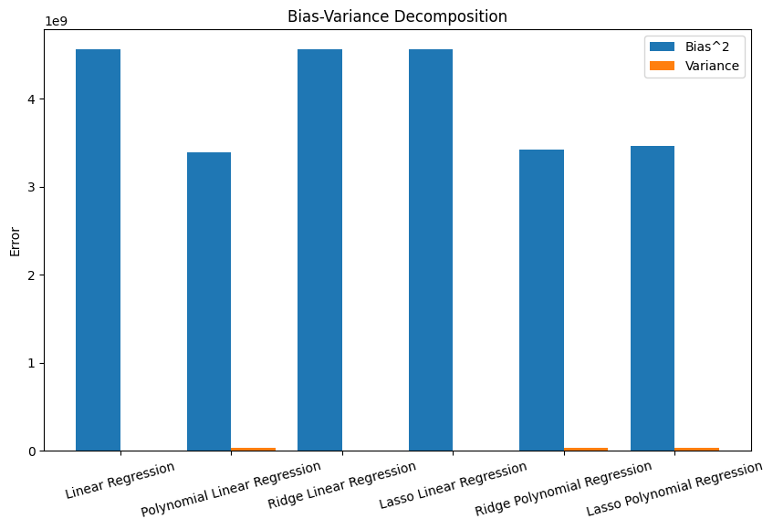

```python
from sklearn.utils import resample

# Parameters
n_iterations = 50  # Number of bootstrap samples for approximation
test_predictions_ridge = []
test_predictions_lasso = []
test_predictions_ridge_poly = []
test_predictions_lasso_poly = []
test_predictions_basic = []
test_predictions_basic_poly = []

# Fit PolynomialFeatures only on training data
from sklearn.preprocessing import PolynomialFeatures
poly = PolynomialFeatures(degree=2)  # Example: Degree 2 for polynomial features
poly.fit(X_train_scaled)  # Fit only once
X_train_poly = poly.transform(X_train_scaled)
X_val_scaled_poly = poly.transform(X_val_scaled)

# Perform bias-variance decomposition for each model
for i in range(n_iterations):
    # Bootstrap sample from the training set
    X_train_sample, y_train_sample = resample(X_train_scaled, y_train)

    # Linear Regression - Basic
    BasicRegression = LinearRegression()
    BasicRegression.fit(X_train_sample, y_train_sample)
    test_predictions_basic.append(BasicRegression.predict(X_val_scaled))

    # Linear Regression - Polynomial
    X_train_sample_poly = poly.transform(X_train_sample)  # Transform bootstrap sample
    BasicPoly = LinearRegression()
    BasicPoly.fit(X_train_sample_poly, y_train_sample)
    test_predictions_basic_poly.append(BasicPoly.predict(X_val_scaled_poly))

    # Ridge Regression - Basic
    ridge = Ridge(alpha=0.9)
    ridge.fit(X_train_sample, y_train_sample)
    test_predictions_ridge.append(ridge.predict(X_val_scaled))

    # Lasso Regression - Basic
    lasso = Lasso(alpha=8)
    lasso.fit(X_train_sample, y_train_sample)
    test_predictions_lasso.append(lasso.predict(X_val_scaled))

    # Ridge Regression - Polynomial
    ridge_poly = Ridge(alpha=0.01)
    ridge_poly.fit(X_train_sample_poly, y_train_sample)
    test_predictions_ridge_poly.append(ridge_poly.predict(X_val_scaled_poly))

    # Lasso Regression - Polynomial
    lasso_poly = Lasso(alpha=0.78, max_iter=10000)
    lasso_poly.fit(X_train_sample_poly, y_train_sample)
    test_predictions_lasso_poly.append(lasso_poly.predict(X_val_scaled_poly))

# Convert lists to numpy arrays
test_predictions_basic = np.array(test_predictions_basic)
test_predictions_basic_poly = np.array(test_predictions_basic_poly)
test_predictions_ridge = np.array(test_predictions_ridge)
test_predictions_lasso = np.array(test_predictions_lasso)
test_predictions_ridge_poly = np.array(test_predictions_ridge_poly)
test_predictions_lasso_poly = np.array(test_predictions_lasso_poly)

# Bias-Variance decomposition function
def bias_variance(y_test, predictions):
    avg_predictions = np.mean(predictions, axis=0)
    bias = np.mean((avg_predictions - y_test) ** 2)
    variance = np.mean(np.var(predictions, axis=0))
    return bias, variance

# Bias-Variance decomposition for each model
bias_basic, variance_basic = bias_variance(y_val, test_predictions_basic)
bias_basic_poly, variance_basic_poly = bias_variance(y_val, test_predictions_basic_poly)
bias_ridge, variance_ridge = bias_variance(y_val, test_predictions_ridge)
bias_lasso, variance_lasso = bias_variance(y_val, test_predictions_lasso)
bias_ridge_poly, variance_ridge_poly = bias_variance(y_val, test_predictions_ridge_poly)
bias_lasso_poly, variance_lasso_poly = bias_variance(y_val, test_predictions_lasso_poly)

# Plot Bias and Variance
models = ['Linear Regression', 'Polynomial Linear Regression', 'Ridge Linear Regression',
          'Lasso Linear Regression', 'Ridge Polynomial Regression', 'Lasso Polynomial Regression']
biases = [bias_basic, bias_basic_poly, bias_ridge, bias_lasso, bias_ridge_poly, bias_lasso_poly]
variances = [variance_basic, variance_basic_poly, variance_ridge, variance_lasso, variance_ridge_poly, variance_lasso_poly]

plt.figure(figsize=(10, 6))
x = np.arange(len(models))
plt.bar(x - 0.2, biases, 0.4, label='Bias^2')
plt.bar(x + 0.2, variances, 0.4, label='Variance')
plt.xticks(x, models, rotation=15)
plt.ylabel("Error")
plt.title("Bias-Variance Decomposition")
plt.legend()
plt.show()

# Graphg is below
```

Our model is underfitting.

In this HW we worked a lot with linear models. It became obvious after VIF tests that there is multicollinearity in this data.

We tried to do many things:

1. Omitting variables (which helped us somehow)
2. Implementing variable selection (which gave us that using all variables is the best option).
3. Trying to encode distances for city agglomeration they are located in.
4. Trying different versions of linear models (Lasso, Ridge, Elastic Net).
5. Trying polynomial features, which gave us significantly higher $R^2$
6. Trying bias-variance decomposition

But all the time we were getting odd results.

1. Coefficents for Ridge, Elastic Net and Lasso were not making sence
2. Gradient descent for Lasso regression was converging only after setting 100K as maximum iterations (which is very costly in terms of computational power).
3. Polynomial features gave better MSE.
4. Bias-Variance decomposition indicated that model is underfitting.

the model is underfitting.

This all gives us an understanding that using Linear Models for this dataset is not a good decision since relationships between X and Y are not linear. Therefore, it would be better to use other models.

## Decision Trees

```python
from sklearn.tree import DecisionTreeRegressor

model = DecisionTreeRegressor(random_state=42, max_depth=5)

# Train the model
model.fit(X_train_scaled, y_train)

# Make predictions
y_pred = model.predict(X_val_scaled)

# Evaluate the model
mse = mean_squared_error(y_val, y_pred)
r2 = r2_score(y_val, y_pred)

# Print evaluation metrics
print(f"Mean Squared Error (MSE): {mse:.2f}")
print(f"R-squared (R2): {r2:.2f}")
```

```
Mean Squared Error (MSE): 5187255807.40
R-squared (R2): 0.61
```

```python
selected_features
```

```
['Median_Income',
 'Distance_to_SanFrancisco',
 'Latitude',
 'Longitude',
 'Distance_to_SanJose',
 'Distance_to_LA',
 'Distance_to_SanDiego']
```

[figure not shown]

```python
feature_importance = model.feature_importances_

    # Plot Feature Importance
plt.figure(figsize=(8, 6))
plt.barh(features_list, feature_importance, color='skyblue')
plt.xlabel('Feature Importance Score')
plt.ylabel('Features')
plt.title('Feature Importance in Decision Tree Regressor')
plt.show()
```

```python
#Grid Search for Decission Trees

param_grid = {
    'max_depth': [2, 3, 4, 5, None],
    'min_samples_split': [2, 5, 10],
    'min_samples_leaf': [1, 2, 4],
    'max_features': [None, 'sqrt', 'log2']
}

# Initialize the model
model = DecisionTreeRegressor(random_state=42)

# GridSearchCV
grid_search = GridSearchCV(estimator=model, param_grid=param_grid,
                           scoring='neg_mean_squared_error', cv=5, verbose=1, n_jobs=-1)

# Fit to training data
grid_search.fit(X_train_scaled, y_train)

# Best parameters
print("Best Parameters:", grid_search.best_params_)

# Best model
best_model = grid_search.best_estimator_
```

```
Fitting 5 folds for each of 135 candidates, totalling 675 fits
Best Parameters: {'max_depth': None, 'max_features': None, 'min_samples_leaf': 4, 'min_samples_split': 10}
```

```python
y_pred = best_model.predict(X_val_scaled)

# Evaluate the model
mse = mean_squared_error(y_val, y_pred)
r2 = r2_score(y_val, y_pred)

# Print evaluation metrics
print(f"Mean Squared Error (MSE): {mse:.2f}")
print(f"R-squared (R2): {r2:.2f}")
```

```
Mean Squared Error (MSE): 3696204082.82
R-squared (R2): 0.72
```

```python
3696204082.82/(10**9)
```

```
3.69620408282
```

[figure not shown]

```python
feature_importance = best_model.feature_importances_

    # Plot Feature Importance
plt.figure(figsize=(8, 6))
plt.barh(features_list, feature_importance, color='skyblue')
plt.xlabel('Feature Importance Score')
plt.ylabel('Features')
plt.title('Feature Importance in Decision Tree Regressor')
plt.show()
```

What can we say here?

1. We see that validation MSE is $3.69*10^9$
2. The most important features are distance to coast and Median Income. Other independent variables are not that inportant.
3. Interesting thing here that location and neighborhood income (or prestige therefore) is more important than housing parameters such as number of bedrooms.